# aIc: am I compositional?

Greg Gloor

04 October, 2022

#### Abstract

Document summary

#### Package

aIc 1.0

# 1 aIc and amIcomp implement simple test functions to determine if a particular dataset and transformation exhibit data pathologies that we can understand and control for. Since ‘all models are wrong’[Box:1976] it is important to know at the outset what is wrong, why it is wrong, and how that wrongness would hinder general interpretability in some way.

To answer the question, posed by the name of the package, “am I compositional?” the answer is always yes! However, a more nuanced answer is that the effect of compositional limitations on the analysis can be large or small depending on the dataset, the normalization and the analysis conducted.

Data normalization is an accepted preprocessing step used to provide desirable statistical characteristics so that the data can be analyzed using standard approaches. These normalizations are usually chosen to address the mean-variance relationship so that differential abundance or linear models can be used to assess how the features differ between groups. However, the effect on other properties of the data are usually not explored when the transformed data are used for dimension reduction and ordination, clustering, feature selection and network analysis. All of these downstream methods assume that distances and correlations between features (anything that has a unique molecular identifier such as a gene, protein, function, operational taxonomic unit, etc) is relatively unaffected by the transformation, although this is generally not examined.

Pathologies in data have knock-on effects for analysis and that one should be aware of this prior to starting an analysis. If the data are behaving as true counts, then our inferences should not change with these alterations. However, it was recognized early on that ‘normalization’ was a key aspect of reproducible analyses. This led to a profusion of normalizations being used during the analysis of high throughput sequencing [Dillies:2013] and several attempts to unify normalization across separate domains of research that all used the same technology platforms [McMurdie:2014, Fernandes:2014]. The realization that HTS instruments delivered multivariate count-compositional data [Friedman:2012,fernandes:2013,Lovell:2015] suggested a way forward. However, there is still considerable uncertainty about the best approaches since non-compositional approaches often appear to give reasonable answers in some contexts.

Therefore, the purpose of this tool is to allow the user to investigate if a particular combination of normalization, dataset and analysis will allow robust interpretations for analyses other than differential abundance or if a different normalization would be better.

One final complication is the number and distribution of 0 values in the dataset. This depends on the makeup of the original samples, and on the sequencing depth. If the groups of samples have different background distributions (say different sets of genes expressed in each group, or different bacterial species in each group), then there will be an asymmetric 0 distribution. If the samples are sequenced too shallowly, then features with low values will drop out and be represented as 0 values. If an asymmetric dataset is sequenced shallowly, then both pathologies will occur. The effect of adjusting the compositional basis (denominator) of the datasets can be explored using the iqlr and lvha approaches that attempt to identify unvarying denominators[Wu2021].

## 1.2 Properties of datasets

# 2 Example functions

The selex dataset[^2] is a useful example because we have a standard of truth, and because it behaves so badly with so many tools since it does not have a predictable relative abundance-variance relationship. It is the test dataset in the ALDEx2 R package[^3].

## 2.1 Sub-compositions and correlation (coherence)

The first test is for correlation in a full dataset and a subset of the data and if different the data are compostions and need to be treated as such. This is a correlation coherence test. Correlations in compositional data are not stable to subsetting and any transformation that is not coherent should not be trusted to build correlation networks unless one is using compositionally appropriate methods.

In other words, correlations change as different filtering and pre-processing steps are performed on the data. If this happens in your data with your transformation do not use correlation, and use a compositionally appropriate measure of association.

```r
test.cor.clr <- aIc.coherent(selex, group=group, zero.method='prior',
  norm.method='clr', log=F, cor.test='spearman')
```

```
## computing center with all features
## computing center with all features
```

```r
test.cor.TMM <- aIc.coherent(selex, group=group, zero.method='prior',
  norm.method='TMM', log=F, cor.test='spearman')
test.cor.clr$is.coherent
```

```
## [1] "No"
```

```r
test.cor.TMM$is.coherent
```

```
## [1] "No"
```

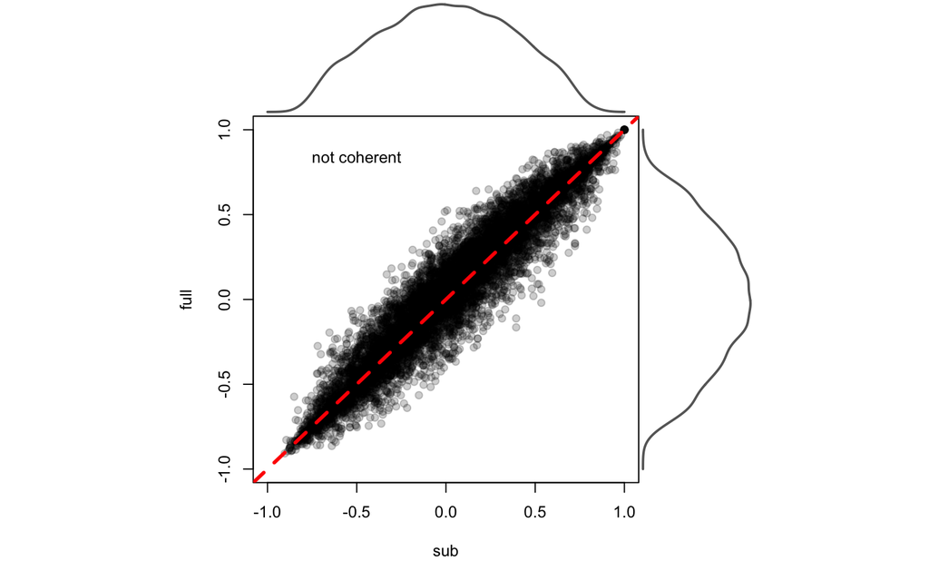

```r
# plot the results
par(mfrow=c(1,2))
aIc.plot(test.cor.clr)
```

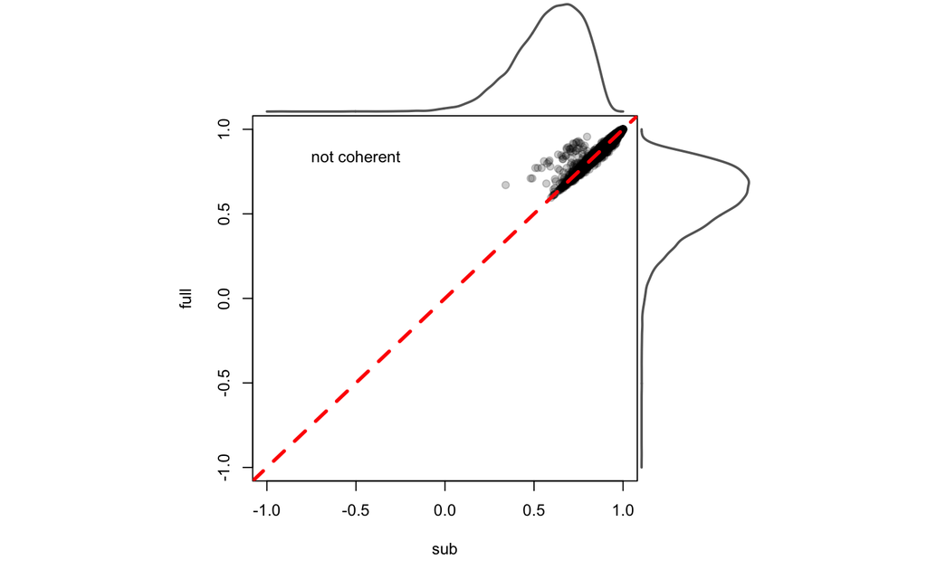

```r
aIc.plot(test.cor.TMM)
```

```r
par(oldrow)
```

## 2.2 Sub-compositions and distance (dominance)

The second test is sub-compositional dominance. That is, the subset data should always have an equal or smaller difference between samples than the full (non-subsetted) dataset. We will use the same dataset and transforms.

```r
test.dom.clr <- aIc.dominant(selex, group=group, zero.method='prior',
  norm.method='clr', log=F)
```

```
## computing center with all features
## computing center with all features
```

```r
test.dom.TMM <- aIc.dominant(selex, group=group, zero.method='prior',
  norm.method='TMM', log=T)
test.dom.clr$is.dominant
```

```
## [1] "Yes"
```

```r
test.dom.TMM$is.dominant
```

```
## [1] "Yes"
```

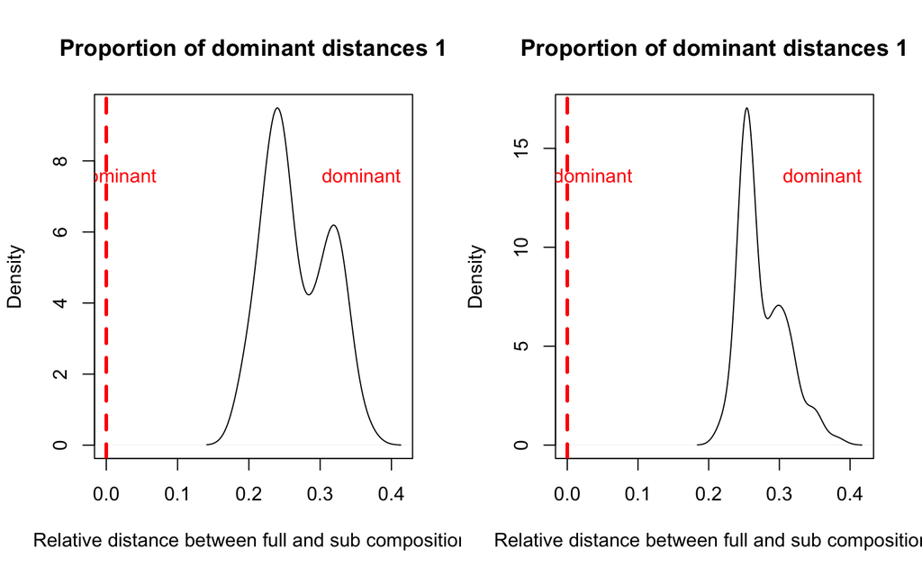

```r
# plot the results
par(mfrow=c(1,2))
aIc.plot(test.dom.clr)
aIc.plot(test.dom.TMM)
```

```r
par(oldrow)
```

Here both transforms are distance dominant and the x-axis is the proportion of divergenece from the distances in the full composition. Both the clr (left) and log TMM distances display a bimodal distribution that is entirely to the right of the red cutoff line of dominance.

## 2.3 Testing for scale invariance

The third test is scale invariance. That is, the data should have the same distance between samples when the scale (sequencing depth) changes. We will use the same dataset and transforms

```r
test.scale.clr <- aIc.scale(selex, group=group, zero.method='GBM',
  norm.method='clr', log=F)
```

```
## computing center with all features
## computing center with all features
```

```r
test.scale.TMM <- aIc.scale(selex, group=group, zero.method='GBM',
  norm.method='TMM', log=T)
test.scale.clr$is.scale
```

```
## [1] "Yes"
```

```r
test.scale.TMM$is.scale
```

```
## [1] "Yes"
```

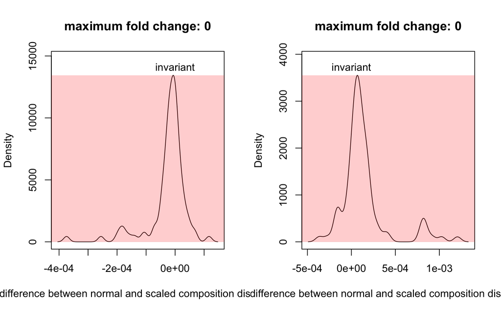

```r
par(mfrow=c(1,2))
aIc.plot(test.scale.clr)
aIc.plot(test.scale.TMM)
```

```r
par(oldrow)
```

Here both transforms are scale invariant within a tolerance of plus or minus 1%. The x-axis is the proportion of divergenece from the distances in the unscaled composition and the red box indicates the limits of the tolerance.

## 2.4 Testing for perturbation invariance

The fourth test is perturbation invariance. That is, the data should have the same distance between samples when one or a few of the features have some perturbation. In the context of a HTS experiment, this could correspond to a systematic difference between the probability of capture of a feature or the probability of sequencing for a subset of the features.

```r
test.perturb.clr <- aIc.perturb(selex, group=group, zero.method='prior',
  norm.method='clr', log=F)
```

```
## computing center with all features
## computing center with all features
```

```r
test.perturb.TMM <- aIc.perturb(selex, group=group, zero.method='prior',
  norm.method='RLE', log=F)
test.perturb.clr$is.perturb
```

```
## [1] "Yes"
```

```r
test.perturb.TMM$is.perturb
```

```
## [1] "No"
```

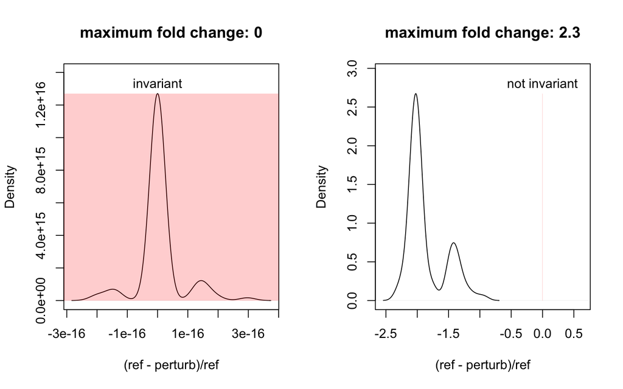

```r
par(mfrow=c(1,2))
aIc.plot(test.perturb.clr)
aIc.plot(test.perturb.TMM)
```

```r
par(oldrow)
```

# 3 Choosing parameters

The tests have common and specific parameters. Common parameters are:

- `norm.method` the normalization method. Other normalization methods will be incorporated on request, but they should be substantially different than the ones given here. For example, the RPKM, FPKM, TPM normalizations are simply scaled versions of proportions and are expected to behave substantially the same as does `prop`.
- `zero.remove` the maximum occurrence of zeros across all samples for a feature. Features with 0 greater than this value will be removed prior to analysis. This is a very conservative filter compared to common practice.
- `zero.method` the 0 replacement strategy. By default we add a prior of 0.5 counts to every value in the data like in the `ALDEx2` package. An alternative is to use the `GBM` method of zero imputation that is instantiated in the `zCompositions` package or to not replace 0s although this causes any logarithm-dependent method to fail. Be cautious with the `GBM` method as it can take some time to run with very large datasets (e.g. single cell).
- `log` take the logarithm of non-logarithmic transforms. Ignored for clr, iqlr and lvha normalization methods since these are log-ratios.
- `group` a group vector since many of the normalizations need group information.
- the `aIc.coherent()` function takes an additional argument to determine the correlation measure and pearson, spearman or kendall are available options.

There is also a `shiny` app that can be used for interactive examination of datasets. This automatically loads the selex dataset, but any tabular count data with samples by column can be used as input. This can be launched with the command: `aIc.runExample()`.

# 4 Conclusion

I hope you can see that data pathologies can have real world implications for your analysis.

The failure of sub-compositional coherence means that any network analysis that is done using anything other than a compositionally appropriate measure is doomed to failure if and when the data are cleaned or otherwise manipulated.

[^1]: Lovell et al. (2015) https://doi.org/10.1371/journal.pcbi.1004075, Quinn et al. (2017) https://doi.org/10.1038/s41598-017-16520-0, Egozcue et al. https://doi.org/10.17713/ajs.v47i1.689, erb:2020
[^2]: McMurrough et al (2018) https://doi.org/10.1093/nar/gky976
[^3]: Fernandes et al (2014) https://doi.org/10.1186/2049-2618-2-15